# Homework

Tan Xin

2021-12-20

# 9-16

## Question

- Use knitr to produce at least 3 examples (texts, figures, tables)

## Answer

- (1)tables:

```r
x <- matrix(seq(1, 9, 1), 3, 3)
knitr::kable(x)
```

| 1 | 4 | 7 |
| --- | --- | --- |
| 2 | 5 | 8 |
| 3 | 6 | 9 |

- (2)figures:

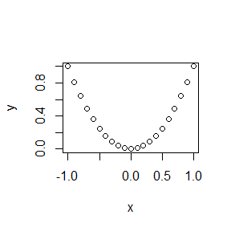

```r
x <- seq(-1, 1, 0.1)
y <- x^2
plot(x, y)
```

- (3)texts:

```r
ymax <- max(y)
```

y的最大值为1.

# 9-23

## Question

- Exercises 3.4, 3.11, and 3.20 (pages 94-96, Statistical Computating with R).

## Answer

### 3.4:

由于$f(x)$形式已知，可以考虑用逆变换法生成随机数。 由$f(x)=\frac{x}{\sigma^2}e^{-x^2/(2\sigma^2)},x\geqslant0$，知:
$$F(x)=\int_{0}^{x}f(t)\mbox{dt}=1-e^{-x^2/(2\sigma^2)}$$
于是$F(x)$的逆$F^{-1}(y)$可计算如下：
$$F^{-1}(y)=\sigma \sqrt{-2\ln(1-y)}$$
在生成随机数过程中，我们分别将$\sigma=1$取为$0.2,1,5,20,50,100$。

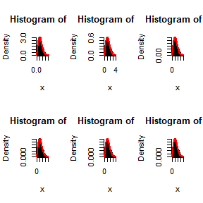

```r
n<-1e3 #每次生成1000个数据
sigma<-c(0.2,1,5,20,50,100)
par(mfrow=c(2,3))
for (i in 1:length(sigma)){
  set.seed(1234)
  u<-runif(n) #生成U~U(0,1)
  x<-sigma[i]*sqrt(-2*log(1-u)) #按sigma从小到大的顺序依次利用F(x)的逆生成X
  upper<-floor(max(x))+1 #找到生成的X的上界，为方便f(x)实际密度函数作图
  t<-seq(from=0,to=upper,by=upper/n)
  hist(x,prob=TRUE,breaks=15)
  lines(t,t*exp(-t*t/2/sigma[i]/sigma[i])/sigma[i]/sigma[i],col='red',lwd=2)#在直方图中作出f(x)实际的密度函数曲线作为对比
}
```

从随机数频率直方图与$f(x)$的实际密度函数曲线的对比中可以看出，在不同的$\sigma$值下，二者的吻合程度均很高，这说明可以认为随机数是服从Rayleigh分布的。

### 3.11:

先生成$p_1=0.75$时的随机数:

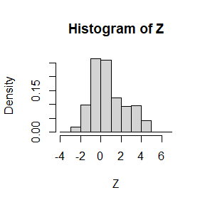

```r
set.seed(1234)
n <- 1000
X1 <- rnorm(n,0,1)
X2 <- rnorm(n,3,1)
r<-sample(c(0,1),n,replace=TRUE,prob=c(0.25,0.75)) #按0.25与0.75的概率比生成0-1分布
Z <- r*X1+(1-r)*X2 #r有0.75的可能取1，于是Z有0.75的可能取X1
hist(Z,prob=TRUE)
```

从$0.3-0.7$，每间隔$0.05$作为一次$p$的取值，通过对比它们的直方图比较双峰性的显著与否。

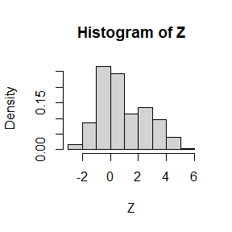

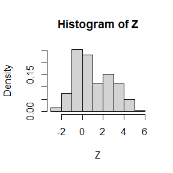

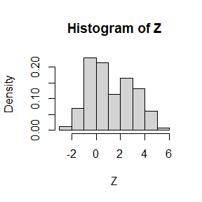

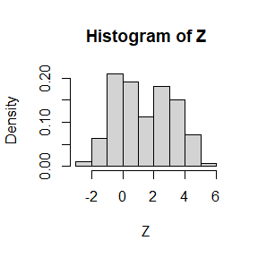

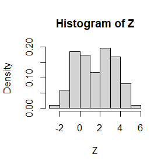

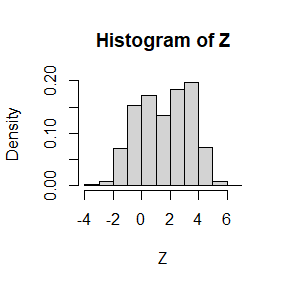

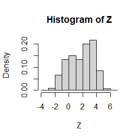

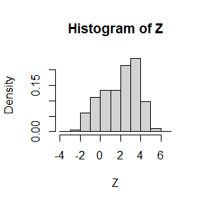

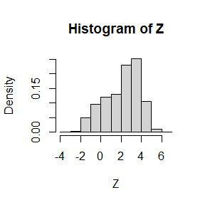

```r
p=seq(0.3,0.7,0.05) #从0.3至0.7每间隔0.05作一次p的取值
#par(mfrow=c(3,3)) #生成3x3直方图,从左至右、从上到下p值依次增大0.5
for (i in 1:length(p)){
  set.seed(1234)
  r<-sample(c(0,1),n,replace=TRUE,prob=c(p[i],1-p[i]))
  Z <- r*X1+(1-r)*X2
  hist(Z,prob=TRUE)
}
```

从$p=0.3,0.35,...,0.65,0.7$生成的混合正态随机数直方图可以看出：当$p$接近$0.5$，尤其在$0.45-0.55$区间时，双峰效应十分显著；当$p\leqslant0.35$或$p\geqslant0.65$时,双峰性较为微弱。

### 3.20:

本题中，设$Y_i\sim \Gamma(a,b)$，于是$X(t)$的理论期望及方差：
$$E[X(t)]=\lambda t E[Y_1]=\frac{a\lambda t}{b}$$
$$Var[X(t)]=\lambda tE[Y_1^2]=\lambda t
(E^2[Y_1]+Var[Y_1])=\frac{(a^2+a)\lambda t}{b^2}$$
我们分别对$(1)\lambda=a=b=1,(2)\lambda=1,a=2,b=5,(3)\lambda=5,a=b=1,(4)\lambda=5,a=2,b=5$四种参数情形进行随机数生成。

```r
set.seed(1234)
lambda <- c(1,1,5,5)
a<-c(1,2,1,2)
b<-c(1,5,1,5)
t0 <- 10
estimate_mean<-numeric(4)
estimate_var<-numeric(4)
theory_mean<-numeric(4)
theory_var<-numeric(4)
for (i in 1:4){
  set.seed(1234)
  X<-replicate(10000, expr = {
    T <- rexp(200, lambda[i])  #interarrival times
    S <- cumsum(T)  #arrival times：cumsum计算累积和S[n]=T[1]+T[2]+...+T[n]
    n <- min(which(S > t0)) #arrivals+1 in [0, t0]： N(t0)为落在[0,t0]区间的次数，故先找到使得S[n]最先超过t0的n，将其-1即为所求
    Y<-rgamma(n-1,a[i],b[i]) #生成N(t)个服从Gamma(a,b)的Y
    sum(Y) #X(t)的取值为这N(t)个Y的总和
    })
  estimate_mean[i]<-mean(X) #计算均值的估计值
  estimate_var[i]<-var(X) #计算方差的估计值
  theory_mean[i]<-lambda[i]*t0*a[i]/b[i] #计算均值的理论值
  theory_var[i]<-lambda[i]*t0*((a[i]+a[i]*a[i])/(b[i]*b[i])) #计算方差的理论值
}
parameters=c('(1,1,1)','(1,2,5)','(5,1,1)','(5,2,5)') #按lambda,a,b的顺序
table1<-cbind(parameters,estimate_mean,theory_mean)
knitr::kable(table1,align='l') #生成期望估计值与理论值的比较表格
```

| parameters | estimate_mean | theory_mean |
| --- | --- | --- |
| (1,1,1) | 10.0128846990827 | 10 |
| (1,2,5) | 3.99231918447474 | 4 |
| (5,1,1) | 50.0323454154176 | 50 |
| (5,2,5) | 19.9926900082647 | 20 |

```r
table2<-cbind(parameters,estimate_var,theory_var)
knitr::kable(table2,align='l') #生成期望估计值与理论值的比较表格
```

| parameters | estimate_var | theory_var |
| --- | --- | --- |
| (1,1,1) | 20.4601371917459 | 20 |
| (1,2,5) | 2.42774211220883 | 2.4 |
| (5,1,1) | 99.5773259565704 | 100 |
| (5,2,5) | 12.0225568076161 | 12 |

从$X(t)$期望和方差的估计值与理论值的对比可以看出，在不同参数取值时，二者均十分接近；当试验次数从10000进一步增加时,最终结果应当会更为接近理论值。

# 9-30

## Question

- Exercises 5.4, 5.9, 5.13, and 5.14 (pages 149-151, Statistical Computating with R).

## Answer

### 5.4:

Write a function to compute a Monte Carlo estimate of the Beta(3, 3) cdf, and use the function to estimate F(x) for x = 0.1, 0.2,…, 0.9. Compare the estimates with the values returned by the pbeta function in R.

$\textbf{解：}$ 运用简单Monte-Carlo方法。对于beta(3,3)在[0,p]上的积分，生成服从[0,p]上均匀分布的随机数，再代入$g(x)$计算近似积分。
$$f(x)=\frac{x^2(1-x)^2}{B(3,3)},\quad g(x)=pf(x)=\frac{px^2(1-x)^2}{B(3,3)},\quad \mbox{其中}B(3,3)=\int_{0}^{1} x^2(1-x)^2 \mbox{dx}$$
$E[g(X)](X\sim U[0,p])$用下式进行近似：
$$\frac{1}{n}\sum_{i=1}^{n}g(X_i),\quad X_i(i.i.d)\sim U[0,p]$$

```r
n<-1e4
p<-seq(0.1,0.9,0.1)
theta.hat<-numeric(length(p))
theta<-numeric(length(p))
for (i in 1:length(p)){
  set.seed(504)
  u<-runif(n,0,p[i])
  theta.hat[i] <- round(p[i]*mean(u*u*(1-u)*(1-u)/beta(3,3)),4)
  theta[i]<-round(pbeta(p[i],3,3),4)
}
table5_4=cbind(p,theta,theta.hat)
knitr::kable(table5_4,align='c')
```

| p | theta | theta.hat |
| --- | --- | --- |
| 0.1 | 0.0086 | 0.0085 |
| 0.2 | 0.0579 | 0.0576 |
| 0.3 | 0.1631 | 0.1623 |
| 0.4 | 0.3174 | 0.3160 |
| 0.5 | 0.5000 | 0.4980 |
| 0.6 | 0.6826 | 0.6802 |
| 0.7 | 0.8369 | 0.8347 |
| 0.8 | 0.9421 | 0.9403 |
| 0.9 | 0.9914 | 0.9905 |

从与真实值的对比结果可以看出，准确程度还是不错的。

### 5.9

The Rayleigh density [156, (18.76)] is $f(x) = \frac{x}{σ^2} e^{−x^2/(2σ^2)}, x ≥ 0,σ> 0.$ Implement a function to generate samples from a Rayleigh(σ) distribution, using antithetic variables. What is the percent reduction in variance of $\frac{X+X'}{2}$ compared with$\frac{X_1+X_2}{2}$ for independent $X_1, X_2$?

$\textbf{解：}$ 密度函数$f(x)=\frac{x}{\sigma^2}exp\{ -\frac{x^2}{2\sigma^2} \}$，故分布函数：
$$F(x)=\int_{0}^{x}f(t)\mbox{dt}=1- \exp \{ -\frac{x^2}{2\sigma^2} \}$$
于是$F(x)$的逆$F^{-1}(y)$可计算如下：
$$F^{-1}(y)=\sigma \sqrt{-2\ln(1-y)}$$
生成$U\sim U[0,1]$后，$X=\sigma \sqrt{-2\ln(1-u)}$。运用对偶变量法，由于$1-U\sim U[0,1]$，可令$X’=\sigma \sqrt{-2\ln [1-(1-U)]}=\sigma \sqrt{-2\ln U}$。本题中，我们选用$\sigma=1$进行计算。

```r
sigma=1
set.seed(123)
u1<-runif(1000) #生成U(0,1)上随机数
x1<-sigma*sqrt(-2*log(1-u1))
x1_new<-sigma*sqrt(-2*log(u1)) #用X1生成其对偶变量X1'
set.seed(1234)
u2<-runif(1000)
x2<-sigma*sqrt(-2*log(1-u2))  #生成新变量X2
c(mean((x1+x1_new)/2),mean((x1+x2)/2))
```

```
## [1] 1.252383 1.261319
```

```r
var_anti<-round(var((x1+x1_new)/2),4)
var_ordinary<-round(var((x1+x2)/2),4)
var_reduction<-round((var_ordinary-var_anti)/var_ordinary,4)
table5_9<-cbind(var_anti,var_ordinary,var_reduction)
knitr::kable(table5_9,align='c')
```

| var_anti | var_ordinary | var_reduction |
| --- | --- | --- |
| 0.0112 | 0.2158 | 0.9481 |

方差减少百分比为94.81%，说明对偶变量法能够实现方差的缩减。

### 5.13

Find two importance functions f1 and f2 that are supported on (1, ∞) and are ‘close’ to $g(x) = \frac{x^2}{\sqrt{2π}} e^{−x^2/2}, x> 1.$ Which of your two importance functions should produce the smaller variance in estimating $\int_{1}^{\infty} \frac{x^2}{\sqrt{2π}} e^{−x^2/2} dx$ by importance sampling? Explain.

$\textbf{解：}$ 这里两个重要函数我们可以选用如下：
$$f_1(x)=x \exp \{-\frac{x^2}{2}\},\quad f_2(x)=\frac{1}{\sqrt{2\pi}} \exp\{ - \frac{x^2}{2} \}$$
$f_1(x)$即为$\sigma=1$时Rayleigh分布的密度函数，服从该分布的随机数可通过逆变换法生成；$f_2(x)$为正态分布的密度函数。

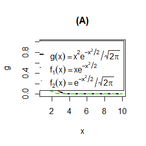

```r
x <- seq(1,10, 0.01)
w <- 2
g <- x^2*exp(-x^2/2)/sqrt(2*pi)
f1 <- x*exp(-x^2/2)
f2 <- exp(-x^2/2)/sqrt(2*pi)

par(mfrow=c(1,1))
gs <- c(expression(g(x)==x^2*e^{-x^2/2}/sqrt(2*pi)),
  expression(f[1](x)==x*e^{-x^2/2}),
  expression(f[2](x)==e^{-x^2/2}/sqrt(2*pi)))
##生成g,f1,f2的图线
plot(x,g,type="l",ylim=c(0,1), lwd = w, lty = 2,col=1,main='(A)')
lines(x,f1,type="l",ylim=c(0,1), lwd = w, lty = 2,col=2,main='(A)')
lines(x,f2,type="l",ylim=c(0,1), lwd = w, lty = 2,col=3,main='(A)')
legend("topright", legend = gs,
       lty = 1:3, lwd = w, inset = 0.02,col=1:3)
```

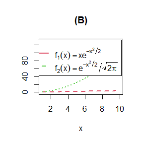

```r
##生成g/f1,g/f2的图线
plot(x, g/f1, type = "l", ylab = "",
     ylim = c(0,130), lwd = w, lty = 2,col=2,main='(B)')
lines(x, g/f2, lty = 3, lwd = w,col=3)
legend("topright", legend = gs[-1],
       lty = 1:3, lwd = w, inset = 0.02,col=2:3)
```

通过图(A)(B)，$g/f_1$相比$g/f_2$变化幅度更小，故可推测通过$f_1$计算的积分有更小的方差。

### 5.14

Obtain a Monte Carlo estimate of $\int_{1}^{\infty} \frac{x^2}{\sqrt{2π}} e^{−x^2/2} dx$ by importance sampling.

$\textbf{解：}$ 选用5.13中的两个重要函数：

```r
m<-1e4
g = function (x) {
  x ^ 2 / sqrt(2*pi) * exp(-x^2/2) *(x>1) #只取>1部分
}
est<-numeric(2)
v<-numeric(2)
##f1计算积分
set.seed(1)
f1 = function (x) {
  x*exp(-x^2/2)
}
u<-runif(m)
x<-sqrt(-2*log(1-u))#逆变换法生成服从Rayleigh分布的随机数X
i <- c(which(x<=1))
x[i] <- -1 #只取>1部分
fg<-g(x)/f1(x)
est[1]<-mean(fg)
v[1]<-var(fg)

##f2计算积分
set.seed(1)
x <- rnorm(1000) #using f2
i <- c(which(x<=1))
x[i] <- -1 #只取>1部分
fg <- g(x) / dnorm(x)
est[2]<-mean(fg)
v[2]<-var(fg)
res <- rbind(estimate=round(est,4), variance=round(v,4))
colnames(res) <- paste0('f',1:2)
knitr::kable(res, align='c')
```

|  | f1 | f2 |
| --- | --- | --- |
| estimate | 0.4008 | 0.4198 |
| variance | 0.1306 | 1.4243 |

通过估计值和方差的对比，$f_1$与$f_2$的积分估计值分别为0.4008和0.4198，比较接近；但$f_1$的方差明显更小，符合9.13中的推测。

# 10-14

## Question

- Exercises 6.5 and 6.A (page 180-181, Statistical Computating with R).
- If we obtain the powers for two methods under a particular simulation setting with 10,000 experiments: say, 0.651 for one method and 0.676 for another method. We want to know if the powers are different at 0.05 level.
1. What is the corresponding hypothesis test problem?
2. What test should we use? Z-test, two-sample t-test, paired-t test or McNemar test? Why?
3. Please provide the least necessary information for hypothesis testing.

### 6.5

Suppose a 95% symmetric t-interval is applied to estimate a mean, but the sample data are non-normal. Then the probability that the confidence interval covers the mean is not necessarily equal to 0.95. Use a Monte Carlo experiment to estimate the coverage probability of the t-interval for random samples of χ2(2) data with sample size n = 20. Compare your t-interval results with the simulation results in Example 6.4. (The t-interval should be more robust to departures from normality than the interval for variance.

### 6.A

Use Monte Carlo simulation to investigate whether the empirical Type I error rate of the t-test is approximately equal to the nominal significance level $\alpha$, when the sampled population is non-normal. The t-test is robust to mild departures from normality. Discuss the simulation results for the cases where the sampled population is (i) $\chi^2(1)$, (ii) Uniform(0,2), and (iii) Exponential(rate=1). In each case, test $H_0: \mu = \mu_0\;vs \;H_1: \mu \neq \mu_0$, where $\mu_0$ is the mean of $\chi^2(1)$, Uniform(0,2), and Exponential(1), respectively.

## Answer

### 6.5:

由t检验的原理,均值的置信区间为$[\bar{X}-\frac{St_{n-1}(1-\frac{\alpha}{2})}{\sqrt{n}},\bar{X}+\frac{St_{n-1}(1-\frac{\alpha}{2})}{\sqrt{n}}]\frac{}{}$.其中$\bar{X}$为样本均值,$S$为样本标准差,$t_{n-1}(1-\frac{\alpha}{2})$为自由度为$n-1$的t分布的上$\alpha/2$分位数.

```r
n<-20
set.seed(1)
n <- 20
alpha <- .05
x_mean<-numeric(1e3)
x_sd<-numeric(1e3)
for (i in 1:1e3){
  x<-rchisq(n,df=2)
  x_mean[i]<-mean(x) #样本均值
  x_sd[i]<-sd(x) #样本标准差
}
t_alpha<-qt(p=1-alpha/2,df=n-1)
coverage<-mean(x_mean-t_alpha*x_sd/sqrt(n)<=2&x_mean+t_alpha*x_sd/sqrt(n)>=2) #所有置信区间中能够覆盖真值2的所占的比例
round(coverage,4)
```

```
## [1] 0.926
```

```r
##例6.4
n <- 20
set.seed(1)
alpha <- .05
UCL <- replicate(1000, expr = {
  x <- rchisq(n, df = 2)
  (n-1) * var(x) / qchisq(alpha, df = n-1)
} )
coverage2<-mean(UCL > 4)
round(coverage2,4)
```

```
## [1] 0.797
```

例6.4中方差的置信区间覆盖率仅为0.797,而本题均值的t置信区间覆盖率则为0.926.相比起来明显与0.95更为接近,说明对于轻微偏离正态的分布,t置信区间更为稳健.

### 6.A:

```r
set.seed(1234)
n <- 1e3
alpha <- 0.1
m <- 5e3 #重复次数
p_x<-p_y<-p_z <- numeric(m) #存储p值
for (j in 1:m) {
  x <- rchisq(n,1) #X^2(1)
  y <- runif(n,0,2) #U(0,2)
  z <- rexp(n,1) #Exp(1)
  ttest_x <- t.test(x,mu=1)
  ttest_y <- t.test(y,mu=1)
  ttest_z <- t.test(z,mu=1)
  p_x[j] <- ttest_x$p.value
  p_y[j] <- ttest_y$p.value
  p_z[j] <- ttest_z$p.value
}

p_chisq.hat <- mean(p_x <= alpha)
p_unif.hat <- mean(p_y <= alpha)
p_exp.hat <- mean(p_z <= alpha)
table1<-rbind(p_chisq.hat,p_unif.hat,p_exp.hat) #3种分布的t1e
knitr::kable(table1,align='l')
```

| p_chisq.hat | 0.1004 |
| --- | --- |
| p_unif.hat | 0.0972 |
| p_exp.hat | 0.0944 |

```r
se_chisq.hat <- sqrt(p_chisq.hat * (1 - p_chisq.hat) / m)
se_unif.hat <- sqrt(p_unif.hat * (1 - p_unif.hat) / m)
se_exp.hat <- sqrt(p_exp.hat * (1 - p_exp.hat) / m)
table2<-rbind(se_chisq.hat,se_unif.hat,se_exp.hat) #3种分布t1e标准差的估计值
knitr::kable(table2,align='l')
```

| se_chisq.hat | 0.0042502 |
| --- | --- |
| se_unif.hat | 0.0041893 |
| se_exp.hat | 0.0041349 |

从三种分布得到的t1e可以看出,与$\alpha=0.1$比较接近,标准差也处于较小的范围.这说明t-test对于轻微偏离正态的分布具有稳健性.

### project:

(1)设两种方法的功效分别为$\alpha_1,\alpha_2$,则检验问题的假设为:
$$H_0:\alpha_1=\alpha_2 \quad vs\quad H_1:\alpha_1\neq\alpha_2$$
(2)可以使用paired t-test.可多次进行两种检验,将每次实验对应的功效值$\alpha_{1,i},\alpha_{2,i}(i=1,2,...,n)$进行配对处理,即对应作差:$\alpha_{1,i}-\alpha_{2,i}$应当近似服从t分布.

(3)检验至少需要的信息:每次实验中两种方法功效的差值$\{ d_i \}_{i=1}^{n}=\{ \alpha_{1,i}-\alpha_{2,i} \}_{i=1}^{n}$.

# 10-21

## Question

- Exercises 6.C (page 180-181, Statistical Computating with R).

### 6.C

Repeat Examples 6.8 and 6.10 for Mardia’s multivariate skewness test. Mardia [187] proposed tests of multivariate normality based on multivariate generalizations of skewness and kurtosis. If X and Y are iid, the multivariate population skewness $β_{1,d}$,is defined by Mardia as
$$\beta_{1,d}= E[(X − \mu)^T Σ^{−1}(Y − \mu)]^3.$$
Under normality, $\beta_{1,d}= 0$. The multivariate skewness statistic is
$$b_{1,d}=\frac{1}{n^2} \sum_{i,j=1}^{n} ((X_i−\bar{X})^T \hat{Σ}^{−1}(X_j−\bar{X}))^3$$
where $\hat{\Sigma}$ is the maximum likelihood estimator of covariance. Large values of $b_{1,d}$are significant. The asymptotic distribution of $nb_{1,d}/6$ is chisquared with $d(d + 1 ) (d + 2 )/6$ degrees of freedom.

## Answer

### 6.C

由题干,假设检验的拒绝域为:
$$W=\{ x:b_{1,d} \geqslant
\frac{6\chi^2_{m}(1-\alpha)}{n} \}, m=d(d + 1 ) (d + 2 )/6$$
协方差阵的极大似然估计$\hat{\Sigma}$:
$$\hat{\Sigma}=\frac{1}{n}\sum_{i=1}^n(X_i−\bar{X}) (X_i−\bar{X})^T$$
其中中心化的s数据阵$X-\bar{X}$:
$$(X_1-\bar{X},...,X_n-\bar{X})=(X_1,...,X_n)
\left( \begin{matrix}
\frac{n-1}{n}&\frac{1}{n}&\cdots&\frac{1}{n}\\
\frac{1}{n}&\frac{n-1}{n}&\cdots&\frac{1}{n}\\
\vdots& &\ddots\\
\frac{1}{n}&\frac{1}{n}&...&\frac{n-1}{n}
\end{matrix} \right)$$
本题中,我们选用均值为$(0,0)$,协方差阵为单位阵的二元正态分布.检验水平$\alpha=0.05$.

(1)首先对于例6.8:

```r
library(MASS)
sk <- function(data) {
  n<-nrow(data)
  d<-ncol(data)
  mu<-numeric(d)
  mat_cent<-diag(1,n)-matrix(1/n,n,n) #中心化X时的右乘矩阵,可以看作单位阵I-所有元素全为1/n的矩阵
  #cov_hat<-t(data)%*%mat_cent%*%data/n
  cov_hat<-cov(data)*(n-1)/n #r中cov函数计算的是修正后的协方差阵,除数是n-1
  data_cent<-mat_cent%*%data #中心化data
  mat_bd<-data_cent%*%solve(cov_hat)%*%t(data_cent) #solve函数求逆矩阵
  b1d<-sum(mat_bd^3)/n^2
  return (b1d)
}

set.seed(123)
n <- c(10,20,30,50,100,300) #每次的样本量
p.reject <- numeric(length(n))
m <- 1000 #每次模拟的重复次数
d<-2 #多元分布的维数
dg<-d*(d+1)*(d+2)/6 #X^2分布的自由度
cv <- qchisq(.95,dg)*6/n #检验临界值
mean<-c(0,0)
sigma<-matrix(c(1,0,0,1),nrow=d,ncol=d)
for (i in 1:length(n)) {
  cnts_reject <- numeric(m) #test decisions
  for (j in 1:m) {
    x <- mvrnorm(n[i],mean,sigma)
    cnts_reject[j] <- as.integer(sk(x) >= cv[i])
  }
  p.reject[i] <- mean(cnts_reject) #拒绝比例
}
table<-rbind(n,p.reject)
knitr::kable(table)
```

| n | 1e+01 | 20.000 | 30.000 | 50.000 | 100.000 | 300.000 |
| --- | --- | --- | --- | --- | --- | --- |
| p.reject | 4e-03 | 0.018 | 0.048 | 0.037 | 0.049 | 0.055 |

从各样本量对应模拟的t1e值可以看出,当样本量较大($\geq50$)时,t1e值与$\alpha$值较为接近.

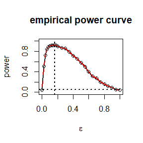

```r
set.seed(123)
alpha <- 0.05
n <- 100 #样本量
m <- 1000 #每次重复的次数
epsilon <- c(seq(0, 0.2, 0.02), seq(0.2, 1, 0.05))
N <- length(epsilon)
power <- numeric(N)
cv <- qchisq(.95,dg)*6/n #检验临界值
Sigma_1<-diag(1,d,d) #MN1的协方差阵
Sigma_10<-diag(10,d,d) #MN2的协方差阵
for (j in 1:N) { #for each epsilon
  e <- epsilon[j]
  cnts_reject <- numeric(m)
  for (i in 1:m) {
    sigma <- sample(c(1, 10), replace = TRUE,
                    size = n, prob = c(1-e, e)) #以概率1-e由N1生成,概率2由多元正态分布2生成
    n_1<-length(which(sigma==1)) #由MN1生成的数量
    n_10<-length(which(sigma==10)) #由MN2生成的数量
    if (n_1>0 & n_10>0){
      x1<-mvrnorm(n_1,mean,Sigma_1)
      x2<-mvrnorm(n_10,mean,Sigma_10)
      x<-rbind(x1,x2)
    }
    else if (n_1>0){
      x<-mvrnorm(n_1,mean,Sigma_1)
    }
    else {
      x<-mvrnorm(n_10,mean,Sigma_10)
    }
    cnts_reject[i] <- as.integer(sk(x) >= cv)
  }
  power[j] <- mean(cnts_reject)
}
plot(epsilon, power, type = "p",
     xlab = bquote(epsilon), ylim = c(0,1),main="empirical power curve")
lines(epsilon,power,lwd=2,col="red")
abline(h =0.05, lty = 3,lwd=2) #直线:y=0.05
se <- sqrt(power * (1-power) / m) #标准差
lines(epsilon, power+se, lty = 3)
lines(epsilon, power-se, lty = 3)
abline(v=0.16,lty=3,lwd=2) #最高点在0.16附近取得
```

```r
table2<-rbind(epsilon,power)
knitr::kable(table2)
```

| epsilon | 0.000 | 0.020 | 0.040 | 0.060 | 0.080 | 0.100 | 0.120 | 0.140 | 0.160 | 0.180 | 0.200 | 0.200 | 0.250 | 0.300 | 0.350 | 0.400 | 0.450 | 0.500 | 0.550 | 0.600 | 0.650 | 0.700 | 0.750 | 0.800 | 0.850 | 0.900 | 0.950 | 1.000 |
| --- | --- | --- | --- | --- | --- | --- | --- | --- | --- | --- | --- | --- | --- | --- | --- | --- | --- | --- | --- | --- | --- | --- | --- | --- | --- | --- | --- | --- |
| power | 0.044 | 0.506 | 0.724 | 0.841 | 0.891 | 0.907 | 0.913 | 0.919 | 0.925 | 0.915 | 0.896 | 0.901 | 0.869 | 0.854 | 0.787 | 0.714 | 0.653 | 0.572 | 0.498 | 0.398 | 0.311 | 0.272 | 0.201 | 0.156 | 0.118 | 0.087 | 0.057 | 0.047 |

当$\epsilon=0,1$时,图线低于$\alpha=0.05$,与此时的确为多元正态分布相吻合;其余部分则均大于$\alpha$,其中大约在$0.16$附近达到最大值.

# 10-28

## Question

- Exercises 7.7 ,7.8 ,7.9 and 7.B (pages 213,Statistical Computating with R).

### 7.7

Refer to Exercise 7.6. Efron and Tibshirani discuss the following example [84,Ch. 7]. The five-dimensional scores data have a 5 × 5 covariance matrix $\Sigma$, with positive eigenvalues $\lambda_1 > ··· > \lambda_5$. In principal components analysis,
$$\theta=\frac{\lambda_1}{\sum_{j=1}^{5}\lambda_j}$$
measures the proportion of variance explained by the first principal component. Let $\hat{\lambda}_1 > ··· > \hat{\lambda}_5$ be the eigenvalues of $\hat{\Sigma}$, where $\hat{\Sigma}$ is the MLE of ${\Sigma}$ Compute the sample estimate
$$\hat{\theta}=\frac{\hat{\lambda}_1}{\sum_{j=1}^{5}\hat{\lambda}_j}$$
of $\theta$. Use bootstrap to estimate the bias and standard error of $\hat{\theta}$.

### 7.8

Refer to Exercise 7.7. Obtain the jackknife estimates of bias and standard error of $\theta$

### 7.9

Refer to Exercise 7.7. Compute 95% percentile and BCa confidence intervals for $\hat{\theta}$.

### 7.B

Repeat Project 7.A for the sample skewness statistic. Compare the coverage rates for normal populations (skewness 0) and $\chi^2(5)$ distributions (positive skewness)

## Answer

### 7.7

```r
library(bootstrap)
attach(scor)
lambda_hat<-eigen(cov(scor))$values #eigen求特征值
theta_hat<-max(lambda_hat)/sum(lambda_hat)
n<-nrow(scor)
B<-1000
set.seed(1234)
theta_B<-numeric(B)
for (i in 1:B){
  ind<-sample(1:n,size=n,replace=TRUE)
  scor_i<-scor[ind,]
  lambda_i<-eigen(cov(scor_i))$values
  theta_B[i]<-max(lambda_i)/sum(lambda_i)
}
theta_B_hat<-mean(theta_B)
bias_B<-theta_B_hat-theta_hat
se_B<-sd(theta_B)
knitr::kable(cbind(theta_B_hat,bias_B,se_B))
```

| theta_B_hat | bias_B | se_B |
| --- | --- | --- |
| 0.6188688 | -0.0002462 | 0.0481896 |

### 7.8:

```r
theta_j<-numeric(n)
for (i in 1:n){
  scor_i<-scor[-i,]
  lambda_i<-eigen(cov(scor_i))$values
  theta_j[i]<-max(lambda_i)/sum(lambda_i)
}
theta_j_hat<-mean(theta_j)
bias_j<-(n-1)*(theta_j_hat-theta_hat)
se_j<-sqrt((n-1)/n*sum((theta_j-theta_j_hat)^2))
knitr::kable(cbind(theta_j_hat,bias_j,se_j),algn='c')
```

| theta_j_hat | bias_j | se_j |
| --- | --- | --- |
| 0.6191273 | 0.0010691 | 0.0495523 |

Jackknife给出的$\theta$估计值为0.6191, bias为0.0011, 标准差为0.0496.

### 7.9:

```r
library(boot)
set.seed(1234)
boot.theta<- function(x,i){
  lambda_i<-eigen(cov(x[i,]))$values
  theta_B<-max(lambda_i)/sum(lambda_i)
  theta_B
}
boot.obj <- boot(scor, statistic = boot.theta, R=500)
ci<-boot.ci(boot.obj, type=c("perc","bca"))
ci.perc<-ci$percent[4:5] ##percentile CI
ci.bca<-ci$bca[4:5] ##Bca CI
knitr::kable(rbind(ci.perc,ci.bca),align='c')
```

| ci.perc | 0.5221962 | 0.7103804 |
| --- | --- | --- |
| ci.bca | 0.5276149 | 0.7222033 |

Bootstrap给出的percentile和BCa置信区间分别为[0.5222,0.7104]和[0.5276,0.7222].

### 7.B

```r
library(boot)
m<-1e3
n<-20
sk <- function(x,i) {
  #computes the sample skewness coeff.
  xbar <- mean(x[i])
  m3 <- mean((x[i] - xbar)^3)
  m2 <- mean((x[i] - xbar)^2)
  return( m3 / m2^1.5 )
}
sk_chi_5 <- sqrt(8/5)
set.seed(0)
ci1.norm<-ci1.basic<-ci1.perc<-ci2.norm<-ci2.basic<-ci2.perc<-matrix(0,m,2)
for(i in 1:m){
  x1<-rnorm(n);x2<-rchisq(n,5)
  de1 <- boot(data=x1,statistic=sk, R = 1e3);de2<-boot(data=x2,statistic=sk,R=2e2)
  ci1 <- boot.ci(de1,type=c("norm","basic","perc"));ci2<-boot.ci(de2,type=c("norm","basic","perc"))
  ci1.norm[i,]<-ci1$norm[2:3];ci2.norm[i,]<-ci2$norm[2:3]
  ci1.basic[i,]<-ci1$basic[4:5];ci2.basic[i,]<-ci2$basic[4:5]
  ci1.perc[i,]<-ci1$percent[4:5];ci2.perc[i,]<-ci2$percent[4:5]
}
#coverage
normal_norm<-mean(ci1.norm[,1]<=0 & ci1.norm[,2]>=0);chisq_norm<-mean(ci2.norm[,1]<=sk_chi_5 & ci2.norm[,2]>= sk_chi_5)
normal_basic<-mean(ci1.basic[,1]<=0 & ci1.basic[,2]>=0);chisq_basic<-mean(ci2.basic[,1]<= sk_chi_5 & ci2.basic[,2]>=sk_chi_5)
normal_perc<-mean(ci1.perc[,1]<=0 & ci1.perc[,2]>=0);chisq_perc<-mean(ci2.perc[,1]<= sk_chi_5 & ci2.perc[,2]>= sk_chi_5)
#the proportion of times that the confidence intervals miss on the left
normal_norm_left<-mean(ci1.norm[,1]>0);chisq_norm_left<-mean(ci2.norm[,1]> sk_chi_5)
normal_basic_left<-mean(ci1.basic[,1]>0);chisq_basic_left<-mean(ci2.basic[,1]> sk_chi_5)
normal_perc_left<-mean(ci1.perc[,1]>0);chisq_perc_left<-mean(ci2.perc[,1]> sk_chi_5)
#the proportion of times that the confidence intervals miss on the right
normal_norm_right<-mean(ci1.norm[,2]<0);chisq_norm_right<-mean(ci2.norm[,2]< sk_chi_5)
normal_basic_right<-mean(ci1.basic[,2]<0);chisq_basic_right<-mean(ci2.basic[,2]< sk_chi_5)
normal_perc_right<-mean(ci1.perc[,2]<0);chisq_perc_right<-mean(ci2.perc[,2]< sk_chi_5)
ci_type <- c("norm", "basic", "perc")
#standard normal
normal_cover <- c(normal_norm, normal_basic, normal_perc)
normal_left<-c(normal_norm_left,normal_basic_left,normal_perc_left)
normal_right<-c(normal_norm_right,normal_basic_right,normal_perc_right)
table1 <- data.frame(ci_type,normal_cover,normal_left,normal_right)
knitr::kable(table1)
```

| ci_type | normal_cover | normal_left | normal_right |
| --- | --- | --- | --- |
| norm | 0.902 | 0.043 | 0.055 |
| basic | 0.897 | 0.048 | 0.055 |
| perc | 0.967 | 0.014 | 0.019 |

```r
#chisq
chisq_cover <- c(chisq_norm, chisq_basic, chisq_perc)
chisq_left<-c(chisq_norm_left,chisq_basic_left,chisq_perc_left)
chisq_right<-c(chisq_norm_right,chisq_basic_right,chisq_perc_right)
table2 <- data.frame(ci_type,chisq_cover,chisq_left,chisq_right)
knitr::kable(table2)
```

| ci_type | chisq_cover | chisq_left | chisq_right |
| --- | --- | --- | --- |
| norm | 0.732 | 0.020 | 0.248 |
| basic | 0.718 | 0.034 | 0.248 |
| perc | 0.719 | 0.000 | 0.281 |

$\chi^2(5)$三者的置信区间覆盖率都在70+%, 均和95%相差很远. 再结合left,right的数据, 可以发现$\chi^2(5)$整体分布具有正的偏度.

# 11-04

## Question

- Exercise 8.2 (page 242, Statistical Computating with R).Implement the bivariate Spearman rank correlation test for independence[255] as a permutation test. The Spearman rank correlation test statistic can be obtained from function cor with method = “spearman”. Compare the achieved significance level of the permutation test with the p-value reported by cor.test on the same samples.
- Design experiments for evaluating the performance of the NN, energy, and ball methods in various situations.
1. Unequal variances and equal expectations
2. Unequal variances and unequal expectations
3. Non-normal distributions: t distribution with 1 df (heavy-tailed distribution), bimodel distribution (mixture of two normal distributions)
4. Unbalanced samples (say, 1 case versus 10 controls) Note: The parameters should be chosen such that the powers are distinguishable (say, range from 0.3 to 0.8)

### 8.2

本题中, 两样本均为随机生成的正态随机数.

```r
set.seed(123)
x <- rnorm(20)
y <- rnorm(20)
R <- 399;z <- c(x, y);K <- 1:length(z);n<-length(x)
reps <- numeric(R);
t0 <- cor(x, y,method="spearman")
for (i in 1:R) {
  ind <- sample(K, size = n) # 置换后x对应的下标
  x1 <- z[ind];y1 <- z[-ind]
  reps[i] <- cor(x1, y1,method="spearman")
}
p <- round(mean(abs(c(t0, reps)) >= t0),3)
p0 <- round(cor.test(x,y,method="spearm")$p.value,3)
round(c(p,p0),3)
```

```
## [1] 0.880 0.881
```

从最终的结果可以看出, 利用置换检验和cor.test得到的p值较为接近, 分别为0.88和0.881, 显著不拒绝两样本独立的原假设.

### Design Experiments

(1)Unequal variances and equal expectations

本题中,选用两样本分别服从分布N(0,1), N(0,1.4).

```r
library("boot")
library("RANN")
library("energy")
library("Ball")

Tn <- function(z, ix, sizes,k) {
  n1 <- sizes[1]; n2 <- sizes[2]; n <- n1 + n2
  if(is.vector(z)) z <- data.frame(z,0);
  z <- z[ix, ];
  NN <- nn2(data=z, k=k+1) # what's the first column?
  block1 <- NN$nn.idx[1:n1,-1]
  block2 <- NN$nn.idx[(n1+1):n,-1]
  i1 <- sum(block1 < n1 + .5); i2 <- sum(block2 > n1+.5)
  (i1 + i2) / (k * n)
}

eqdist.nn <- function(z,sizes,k){
  boot.obj <- boot(data=z,statistic=Tn,R=R,
                   sim = "permutation", sizes = sizes,k=k)
  ts <- c(boot.obj$t0,boot.obj$t)
  p.value <- mean(ts>=ts[1])
  list(statistic=ts[1],p.value=p.value)
}

m <- 3e2; k<-3; p<-2; mu <- 0.3; set.seed(123)
n1 <- n2 <- 50; R<-99; n <- n1+n2; N = c(n1,n2)
p.values <- matrix(NA,m,3)
for(i in 1:m){
  x <- matrix(rnorm(n1*p,0,1),ncol=p);
  y <- matrix(rnorm(n2*p,0,1.4),ncol=p)
  z <- rbind(x,y)
  p.values[i,1] <- eqdist.nn(z,N,k)$p.value
  p.values[i,2] <- eqdist.etest(z,sizes=N,R=R)$p.value
  p.values[i,3] <- bd.test(x=x,y=y,num.permutations=99,seed=i)$p.value
}
alpha <- 0.1;
name<- c('knn','energy','ball')
power <- colMeans(p.values<alpha)
knitr::kable(rbind(name,power),align="c")
```

| name | knn | energy | ball |
| --- | --- | --- | --- |
| power | 0.316666666666667 | 0.396666666666667 | 0.756666666666667 |

在期望相同, 方差不同情形下, ball检验的power明显最好, 优于knn和energy检验.

(2)Unequal variances and unequal expectations

本题中,选用两样本分别服从分布N(0,1), N(0.3,1.2).

```r
set.seed(123)
for(i in 1:m){
  x <- matrix(rnorm(n1*p,0,1),ncol=p);
  y <- matrix(rnorm(n2*p,0.3,1.2),ncol=p)
  z <- rbind(x,y)
  p.values[i,1] <- eqdist.nn(z,N,k)$p.value
  p.values[i,2] <- eqdist.etest(z,sizes=N,R=R)$p.value
  p.values[i,3] <- bd.test(x=x,y=y,num.permutations=99,seed=i)$p.value
}
alpha <- 0.1;
power <- colMeans(p.values<alpha)
knitr::kable(rbind(name,power),align="c")
```

| name | knn | energy | ball |
| --- | --- | --- | --- |
| power | 0.286666666666667 | 0.576666666666667 | 0.62 |

在均值和方差均不同的情形下, energy和ball检验表现相近, 优于knn.

3. Non-normal distributions: t distribution with 1 df (heavy-tailed distribution), bimodel distribution (mixture of two normal distributions)

本题中, 混合正态分布选为: 0.5N(0,1)+0.5N(0,1.3).

```r
set.seed(1234)
for(i in 1:m){
  x<-matrix(rt(n1*p,df=1),ncol=p)
  y <-rnorm(n2 * p,mean=c(0,0),sd = sample(c(1,1.3), prob = c(0.5,0.5),replace = TRUE))
  y<- matrix(y,ncol=p)
  z <- rbind(x,y)
  p.values[i,1] <- eqdist.nn(z,N,k)$p.value
  p.values[i,2] <- eqdist.etest(z,sizes=N,R=R)$p.value
  p.values[i,3] <- bd.test(x=x,y=y,num.permutations=99,seed=i)$p.value
}
alpha <- 0.1;
power <- colMeans(p.values<alpha)
knitr::kable(rbind(name,power),align="c")
```

| name | knn | energy | ball |
| --- | --- | --- | --- |
| power | 0.763333333333333 | 0.983333333333333 | 0.99 |

在非正态情形下, energy和ball检验表现相近, 比knn更好.

4. Unbalanced samples (say, 1 case versus 10 controls)

本题中, 样本量分别选为50和5, 分别服从分布N(0,1), N(0.9,1).

```r
n1 <- 50;n2 <- 5;n <- n1+n2;N = c(n1,n2)
for(i in 1:m) {
  x <- matrix(rnorm(n1*p,0,1), ncol = p)#50 samples
  y <- matrix(rnorm(n2*p,0.9,1), ncol = p)#5 samples
  z <- rbind(x, y)
  p.values[i, 1] <- eqdist.nn(z, N, k)$p.value
  p.values[i, 2] <- eqdist.etest(z, sizes = N, R = R)$p.value
  p.values[i, 3] <- bd.test(x = x, y = y, R = 99, seed = i)$p.value
}
alpha <- 0.1
power <- colMeans(p.values<alpha)
knitr::kable(rbind(name,power),align="c")
```

| name | knn | energy | ball |
| --- | --- | --- | --- |
| power | 0.366666666666667 | 0.743333333333333 | 0.483333333333333 |

在不平衡样本情形下, energy检验表现最好, ball 检验次之, 最后是knn 检验.

# 11-11

## Question

- Exercies 9.3 and 9.8 (pages 277-278, Statistical Computating with R).
- For each of the above exercise, use the Gelman-Rubin method to monitor convergence of the chain, and run the chain until it converges approximately to the target distribution according to $\hat{R}<1.2$

### 9.3

Use the Metropolis-Hastings sampler to generate random variables from a standard Cauchy distribution. Discard the first 1000 of the chain, and com- pare the deciles of the generated observations with the deciles of the standard Cauchy distribution (see qcauchyor qt with df=1). Recall that a Cauchy(θ,η) distribution has density function
$$f(x)=\frac{1}{\theta \pi(1+[(x-\eta)/\theta]^2)},-\infty<x<\infty,\theta>0$$
The standard Cauchy has the Cauchy(θ = 1,η = 0) density. (Note that the standard Cauchy density is equal to the Student t density with one degree of freedom.)

### 9.8

This example appears in [40]. Consider the bivariate density
$$f(x,y) \propto \left(
\begin{matrix}
n\\
x
\end{matrix}
\right) y^{x+a-1}(1-y)^{n-x+b-1}, x=0,1,...,n, 0\leq y\leq 1$$
It can be shown (see e.g. [23]) that for fixed a,b,n, the conditional distribu- tions are Binomial(n,y) and Beta(x+a,n−x+b). Use the Gibbs sampler to generate a chain with target joint density f(x,y).

## Answer

### 9.3

提议分布$g$选用对称分布$N(X_t,\sigma^2)$, 故$g(X_t)=g(Y)$,
$$\alpha(X_t,Y)=\min(1,\frac{f(Y)g(X_t)}{f(X_t)g(Y)})=\min(1,\frac{f(Y)}{f(X_t)})$$

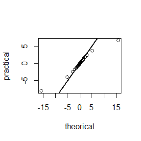

```r
cauchy.metropolis<-function(sigma,x0,N){
  x<-numeric(N)
  x[1]<-x0
  u<-runif(N)
  k<-0
  for (i in 2:N){
    y<-rnorm(1,x[i-1],sigma)
    if (u[i]<=dcauchy(y)/dcauchy(x[i-1]))
      x[i]<-y
    else {
      x[i]<-x[i-1]
      k<-k+1
    }
  }
  x
}
set.seed(1234)
N<-5000 #链长为5000
sigma<-2.5 #sigma值选为2.5
x0<-0 #初值选为0
burn<-1e3 #预烧期为1000
chain<-cauchy.metropolis(sigma,x0,N)
#plot(chain,type="l")
a<-ppoints(25)
QR<-qcauchy(a)
Q<-quantile(chain[(burn+1):N],a)
qqplot(QR,Q,xlab="theorical",ylab="practical")
abline(c(0,0),c(1,1),lwd=2)
```

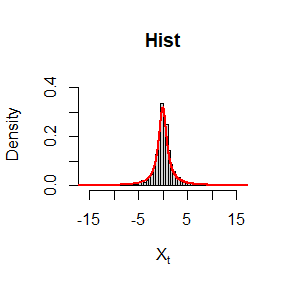

```r
hist(chain[(burn+1):N],breaks="scott",freq=FALSE,ylim=c(0,0.1+1/pi),main="Hist",xlab=expression(X[t]))
lines(seq(-20,20,0.01),dcauchy(seq(-20,20,0.01)),lwd=2,col="red")
```

### 9.8

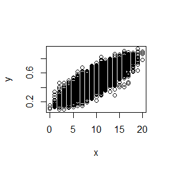

```r
gibbs<-function(n,a,b,x0,N=5000){
  X <- matrix(0, N, 2)
  X[1, ] <- x0
  for (i in 2:N){
    x2 <- X[i-1,2]
    X[i,1]<-rbinom(1,n,x2)
    x1<-X[i,1]
    X[i,2]<-rbeta(1,x1+a,n-x1+b)
  }
  X
}
x0<-c(10,0.5) #x,y初值分别选为10,0.5
a<-b<-5;n<-20 #a,b,n,分别选为5,5,20
X<-gibbs(n,a,b,x0,N)
burn<-1000
x<-X[(burn+1):N,]
plot(x,xlab="x",ylab="y")
```

```r
#knitr::kable(t(colMeans(x))) #x,y均值
```

### Gelman-Rubin

```r
Gelman.Rubin <- function(psi) {
  # psi[i,j] is the statistic psi(X[i,1:j])
  # for chain in i-th row of X
  psi <- as.matrix(psi)
  n <- ncol(psi)
  k <- nrow(psi)
  psi.means <- rowMeans(psi) #row means
  B <- n * var(psi.means) #between variance est.
  psi.w <- apply(psi, 1, "var") #within variances
  W <- mean(psi.w) #within est.
  v.hat <- W*(n-1)/n + (B/n) #upper variance est.
  r.hat <- v.hat / W #G-R statistic
  return(r.hat)
}

## 9.3
set.seed(1234)
k <- 4 #生成链的条数
N <- 5000 #每条链的长度
burn <- 2000 #预烧期
x0 <- c(-5, -2, 2, 5) #4个不同初值
X <- matrix(0, nrow=k, ncol=N)
sigma<-2.5
for (i in 1:k)
  X[i, ] <- cauchy.metropolis(sigma, x0[i],N)
psi <- t(apply(X, 1, cumsum)) #cumsum计算累加和
for (i in 1:nrow(psi))
  psi[i,] <- psi[i,] / (1:ncol(psi)) #psi储存累积均值; 1:ncol(psi)对应每个时刻的链长
print(Gelman.Rubin(psi))
```

```
## [1] 1.164304
```

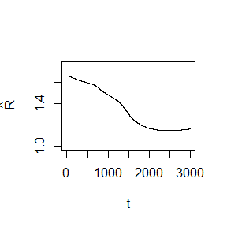

```r
# par(mfrow=c(2,2))
# for (i in 1:k)
#   plot(psi[i, (b+1):N], type="l",xlab=i, ylab=bquote(psi))
par(mfrow=c(1,1))
r.hat <- rep(0, (N-burn))
for (j in (burn+1):N)
  r.hat[j-burn] <- Gelman.Rubin(psi[,1:j])#生成Gelman-Rubin统计量r.hat
plot(r.hat, type="l", xlab="t", ylab=expression(hat(R)),ylim=c(1,max(r.hat)+0.1))
abline(h=1.2, lty=2) #临界值1.2
```

```r
##9.8
set.seed(123)
k <- 4 #生成链的条数
N <- 10000 #每条链的长度
burn <- 1000 #预烧期
X0<-matrix(c(7,0.6,10,0.55,10,0.45,13,0.4),ncol=2,nrow=4,byrow=TRUE)
X1 <- matrix(0, nrow=k, ncol=N)
X2 <- matrix(0, nrow=k, ncol=N)
for (i in 1:k){
  X1[i, ] <- gibbs(n,a,b,X0[i,],N)[,1]
  X2[i, ] <- gibbs(n,a,b,X0[i,],N)[,2]
}

psi1 <- t(apply(X1, 1, cumsum)) #cumsum计算累加和
psi2 <- t(apply(X2, 1, cumsum))
for (i in 1:nrow(psi1)){
  psi1[i,] <- psi1[i,] / (1:ncol(psi1)) #psi储存累积均值; 1:ncol(psi)对应每个时刻的链长
  psi2[i,] <- psi2[i,] / (1:ncol(psi2))
}
print(c(Gelman.Rubin(psi1),Gelman.Rubin(psi2)))
```

```
## [1] 1.136941 1.192141
```

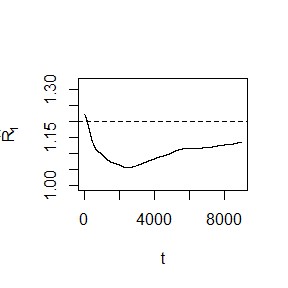

```r
par(mfrow=c(1,1))
r1.hat <- r2.hat <- rep(0, (N-burn))
for (j in (burn+1):N){
  r1.hat[j-burn] <- Gelman.Rubin(psi1[,1:j])#生成Gelman-Rubin统计量r.hat
  r2.hat[j-burn] <- Gelman.Rubin(psi2[,1:j])
}
plot(r1.hat, type="l", xlab="t", ylab=expression(hat(R[1])),ylim=c(1,max(r1.hat)+0.1))
abline(h=1.2, lty=2) #临界值1.2
```

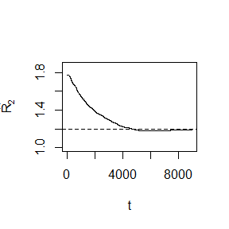

```r
plot(r2.hat, type="l", xlab="t", ylab=expression(hat(R[2])),ylim=c(1,max(r2.hat)+0.1))
abline(h=1.2, lty=2) #临界值1.2
```

# 11-18

## Question

- Exercises 11.3 and 11.5 (pages 353-354, Statistical Computing with R)
- Suppose T1, . . . , Tn are i.i.d. samples drawn from the exponential distribution with expectation λ. Those values greater than τ are not observed due to right censorship, so that the observed values are $Y_i = T_i I(T_i ≤ \tau ) + \tau I(T_i > τ ),i = 1, . . . , n.$ Suppose $\tau = 1$ and the observed $Y_i$ values are as follows:
  $$0.54, 0.48, 0.33, 0.43, 1.00, 1.00, 0.91, 1.00, 0.21, 0.85.$$
  Use the E-M algorithm to estimate λ, compare your result with the observed data MLE (note: $Y_i$ follows a mixture distribution)

### 11.3

```r
###(1)
f_k<-function(a,k){
  d<-length(a)
  a_mod<-sqrt(as.numeric(a%*%a)) #计算a的2-范数
  f_k0<-a_mod^2*gamma((d+1)/2)*(gamma(3/2))/gamma(d/2+1)/2 #k=0时单独计算
  if (k==0){
    return (f_k0)
  }
  else {return ( (-1)^k * exp(log(gamma((d+1)/2)) + log(gamma(k+3/2)) -
                                log(gamma(k+d/2+1)) - sum(log(seq(1,k,1))) - k*log(2) +
                                (2*k+2)*log(a_mod) - log(2*k+1) - log(2*k+2)))} #防止超界先取对数
}

###(2)
f_sum<-function(a){
  k<-0
  s<-0
  while (abs(f_k(a,k))>=1e-6){
    s<-s+f_k(a,k)
    k<-k+1
  } #只计算>10^{-6}的项
  return (s)
}
###(3)
a<-c(1,2)
print(round(f_sum(a),4))
```

```
## [1] 1.5322
```

$a=(1,2)^T$代入计算得到的结果为1.5322.

### 11.5

记自由度为$k$的t分布的密度函数为$f_k$, 则等式左右两端分别可看作$2f_{k-1},2f_k$在$[0,c_k]$上的积分.

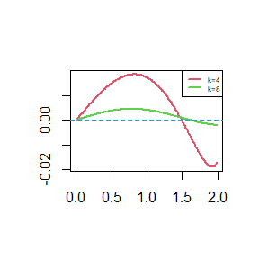

```r
# g <- function(u,k){
#   return ((1+u^2/k)^(-(k+1)/2))
# }
# I <- function(a,k){
#   ck<-sqrt(a^2*k/(k+1-a^2))
#   I1<-integrate(g,lower=0,upper=ck,k=k)$value
#   return (2*exp(log(gamma((k+1)/2))-log(gamma(k/2)))/sqrt(pi*k)*I1)
# }
I<-function(a,k){
  ck<-sqrt(a^2*k/(k+1-a^2))
  return (2*integrate(dt,lower=0,upper=ck,df=k)$value)
}
diff<-function(a,k){
  I(a,k)-I(a,k-1)
}
#为确定根的范围, 作出下列a-diff图示
k0<-c(4,8,15,25,100,500,1000)
a <- seq(0, sqrt(4)-1e-2, by=0.01)
res<-matrix(0,ncol=length(a),nrow=length(k0))
for (i in 1:length(k0)){
  for (j in 1:length(a)){
    res[i,j]=diff(a[j],k0[i])
  }
}
#分四组分别做出图示
#par(mfrow=c(2,2))
plot(a,res[1,],col=2,type="l",lwd=2,ylab="",xlab="")
lines(a,res[2,],col=3,lwd=2)
abline(h=0,col=4,lty=2)
legend("topright",col=2:3,cex=0.5,legend=c("k=4","k=8"),lwd=rep(2,2))
```

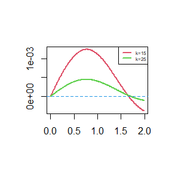

```r
plot(a,res[3,],col=2,lwd=2,type="l",main="",ylab="",xlab="")
lines(a,res[4,],col=3,lwd=2)
abline(h=0,col=4,lty=2)
legend("topright",col=2:3,cex=0.5,legend=c("k=15","k=25"),lwd=rep(2,2))
```

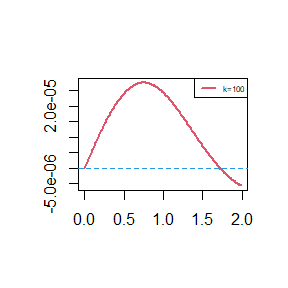

```r
plot(a,res[5,],col=2,type="l",lwd=2,main="",ylab="",xlab="")
abline(h=0,col=4,lty=2)
legend("topright",col=2:3,cex=0.5,legend="k=100",lwd=2)
```

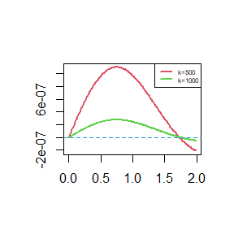

```r
plot(a,res[6,],col=2,type="l",lwd=2,main="",ylab="",xlab="")
lines(a,res[7,],col=3,lwd=2)
abline(h=0,col=4,lty=2)
legend("topright",col=2:3,cex=0.5,legend=c("k=500","k=1000"),lwd=rep(2,2))
```

```r
#从上述图线中可以发现(1,2)之间均存在零点, 故可以猜想uniroot的搜索区间定为[1,2].
#为此给出k不同取值时在a=1,2处的值.

k<-c(4:25,100,500,1000)
for (i in 1:length(k)){
  print(round(c(k[i],diff(1,k[i]),diff(2,k[i])),7))
}
```

```
## [1]  4.0000000  0.0171013 -0.0161301
## [1]  5.0000000  0.0106835 -0.0089009
## [1]  6.0000000  0.0072998 -0.0049887
## [1]  7.0000000  0.0053010 -0.0031258
## [1]  8.0000000  0.0040232 -0.0021197
## [1]  9.0000000  0.0031571 -0.0015223
## [1] 10.0000000  0.0025433 -0.0011415
## [1] 11.0000000  0.0020924 -0.0008851
## [1] 12.0000000  0.0017516 -0.0007050
## [1] 13.0000000  0.0014878 -0.0005739
## [1] 14.0000000  0.0012793 -0.0004757
## [1] 15.0000000  0.0011118 -0.0004004
## [1] 16.0000000  0.0009752 -0.0003414
## [1] 17.0000000  0.0008622 -0.0002944
## [1] 18.0000000  0.0007678 -0.0002564
## [1] 19.0000000  0.0006881 -0.0002252
## [1] 20.0000000  0.0006202 -0.0001993
## [1] 21.0000000  0.0005619 -0.0001776
## [1] 22.0000000  0.0005114 -0.0001592
## [1] 23.0000000  0.0004675 -0.0001435
## [1] 24.0000000  0.0004289 -0.0001300
## [1] 25.0000000  0.0003950 -0.0001184
## [1]  1.00e+02  2.43e-05 -5.90e-06
## [1]  5e+02  1e-06 -2e-07
## [1]  1e+03  2e-07 -1e-07
```

```r
#可以看到, 在k不同取值时1,2处符号均相反. 故[1,2]中一定存在根.

roots<-numeric(length(k))
for (i in 1:length(k)){
  roots[i]<-uniroot(function(a){diff(a,k[i])},lower=1,upper=2)$root
}
knitr::kable((cbind(k,round(roots,3))))
```

| k |  |
| --- | --- |
| 4 | 1.492 |
| 5 | 1.534 |
| 6 | 1.563 |
| 7 | 1.584 |
| 8 | 1.601 |
| 9 | 1.615 |
| 10 | 1.625 |
| 11 | 1.634 |
| 12 | 1.642 |
| 13 | 1.649 |
| 14 | 1.654 |
| 15 | 1.659 |
| 16 | 1.663 |
| 17 | 1.667 |
| 18 | 1.671 |
| 19 | 1.674 |
| 20 | 1.677 |
| 21 | 1.679 |
| 22 | 1.681 |
| 23 | 1.684 |
| 24 | 1.686 |
| 25 | 1.687 |
| 100 | 1.721 |
| 500 | 1.730 |
| 1000 | 1.731 |

```r
##题11.4
S<-function(a,k){
  tk<-sqrt(a^2*k/(k+1-a^2))
  return (1-pt(tk,df=k))
}
A<-function(a,k){
  return (S(a,k)-S(a,k-1))
}
k<-c(4:25,100,500,1000)
roots2<-numeric(length(k))
for (i in 1:length(k)){
  roots2[i]<-uniroot(function(a){A(a,k[i])},lower=1,upper=2)$root
}
knitr::kable((cbind(k,round(roots2,3))))
```

| k |  |
| --- | --- |
| 4 | 1.492 |
| 5 | 1.534 |
| 6 | 1.563 |
| 7 | 1.584 |
| 8 | 1.601 |
| 9 | 1.615 |
| 10 | 1.625 |
| 11 | 1.634 |
| 12 | 1.642 |
| 13 | 1.649 |
| 14 | 1.654 |
| 15 | 1.659 |
| 16 | 1.663 |
| 17 | 1.667 |
| 18 | 1.671 |
| 19 | 1.674 |
| 20 | 1.677 |
| 21 | 1.679 |
| 22 | 1.681 |
| 23 | 1.684 |
| 24 | 1.686 |
| 25 | 1.687 |
| 100 | 1.721 |
| 500 | 1.730 |
| 1000 | 1.731 |

对比可以发现题11.5与题11.4的结果相同.

### EM

#### (1) EM算法:

记满足$I(T_i\leq \tau)=1$的观察值为$y_1,...,y_{n_1}$, 则剩余未观测到实际值的$T_i$有$n-n_1$个, 其观测值$y_{n_1+1}=...=y_{n}=1$.记其真实值为$Z_1,...,Z_{n_2}$. 则基于完整数据$y,z)$的似然函数:
$$\begin{align*}
L(y,z,\lambda)&=\lambda^{-n} e^{-\frac{1}{\lambda}(\sum_{j=1}^{n_1} y_j+\sum_{j=1}^{n_2} z_j)}\\
l(y,z,\lambda)&=-n \ln \lambda- \frac{1}{\lambda} (\sum_{j=1}^{n_1} y_j+\sum_{j=1}^{n_2} z_j)
\end{align*}$$

**E步**: 在第i步迭代完成后, 记此时得到的迭代参数值为$\lambda^{(i)}$. 则对数似然函数为:
$$Q(\lambda|\lambda^{(i)})=-n \ln \lambda- \frac{1}{\lambda} (\sum_{j=1}^{n_1} y_j+\sum_{j=1}^{n_2} E[z_j|\lambda^{(i)},y])$$
下面求解$z_j$的分布:
$$\begin{align*}
P(z_j-\tau\leq u|I(z_j>\tau)=1)&=1-P(z_j > u + \tau |z_j>\tau)\\
&=1-P(z_j > u)=P(z_j\leq u)
\end{align*}$$
其中第二个等号由指数分布的无后效性得到.由此,
$$z_j-\tau|(\lambda^{(i)},y) \sim Exp(1/\lambda^{(i)})\implies E[z_j|\lambda^{(i)},y] = \tau + \lambda^{(i)}$$
故
$$Q(\lambda|\lambda^{(i)})=-n \ln \lambda- \frac{1}{\lambda}(\sum_{j=1}^{n_1} y_j+\sum_{j=1}^{n_2} (\tau + \lambda^{(i)}))$$

**M步**：

对上式求导:
$$\begin{align*}
\frac{\partial Q(\lambda|\lambda^{(i)})}{\partial \lambda} &= -\frac{n}{\lambda} + \frac{1}{\lambda^2} (\sum_{j=1}^{n_1} y_j+\sum_{j=1}^{n_2} (\tau + \lambda^{(i)}))=0\\
\implies \lambda^{(i+1)}&=\frac{\sum_{j=1}^{n_1} y_j+\sum_{j=1}^{n_2} (\tau + \lambda^{(i)})}{n}=\frac{\sum_{j=1}^{n_1} y_j +n_2(\tau+\lambda^{(i)})}{n}
\end{align*}$$

依据上述推导, 迭代程序如下:

```r
y<-c(0.54, 0.48, 0.33, 0.43, 1.00, 1.00, 0.91, 1.00, 0.21, 0.85)
tau<-1
x<-y[y!=1.00]
n<-length(y)
n1<-length(x)
n2<-n-n1
s<-sum(x)
lambda<-seq(1,100,1)
for (i in 2:100){
  lambda[i]<-(s+(n2*(lambda[i-1]+tau)))/n
  if (abs(lambda[i]-lambda[i-1])<1e-6){
    break
  }
}
name<-c("times","lambda")
knitr::kable(rbind(name,round(c(i,lambda[i]),4)))
```

| name | times | lambda |
| --- | --- | --- |
|  | 11 | 0.9643 |

事实上, 设$\{\lambda^{(i)}\}_{i\geq 1}$的收敛值为$\lambda^*$, 则有
$$\lambda^*=\frac{\sum_{j=1}^{n_1} y_j +n_2(\tau+\lambda^*)}{n} \implies \lambda^*=\frac{\sum_{j=1}^{n_1} y_j +n_2\tau}{n_1}$$

代入计算得到$\lambda^*=$ 0.9643, 与迭代结果值一致.

#### (2) MLE

$$P(y_j >\tau)=\int_{\tau}^{\infty} \frac{1}{\lambda} e^{-\frac{y}{\lambda}} dy= e^{-\frac{\tau}{\lambda}}$$

似然函数:
$$\begin{align*}
L(y,\lambda)&=\prod_{j=1}^{n_1} f(y_j,\lambda) \prod_{j}^{n_2}P(y_j>\tau)\\
&=\lambda^{-n_1} e^{- \frac{1}{\lambda} \sum_{j=1}^{n_2} y_j} e^{-\frac{n_2\tau}{\lambda}}=\lambda^{-n_1} e^{- \frac{1}{\lambda} (\sum_{j=1}^{n_2} y_j + n_2 \tau)}\\
l(y,\lambda) &= -n_1 \ln \lambda - \frac{1}{\lambda} (\sum_{j=1}^{n_2} y_j + n_2 \tau)
\end{align*}$$
对上式求导:
$$\begin{align*}
\frac{\partial l(y,\lambda)}{\partial \lambda} &= -\frac{n_1}{\lambda}+\frac{\sum_{j=1}^{n_2} y_j + n_2 \tau}{\lambda^2} =0 \\
\implies \hat{\lambda}_{MLE} &= \frac{\sum_{j=1}^{n_2} y_j + n_2 \tau}{n_1}
\end{align*}$$

代入计算, 得到$\hat{\lambda}_{MLE}=$ 0.9643. 事实上与EM得到的结果一致.

# 11-25

## Question

- Exercises 1 and 5 (page 204, Advanced R)
- Excecises 1 and 7 (page 214, Advanced R)

### Exercises 1 (P204)

```r
set.seed(12345)
bootstraps <- lapply(1:10, function(i) {
  rows <- sample(1:nrow(mtcars), rep = TRUE)
  mtcars[rows, ]
})

# for循环
lm_for = vector("list", 10)
for (i in 1:10){
  x<-bootstraps[[i]]
  lm_for[[i]]<-lm(mpg ~ wt, data = x)
}
lm_for
```

```
## [[1]]
##
## Call:
## lm(formula = mpg ~ wt, data = x)
##
## Coefficients:
## (Intercept)           wt
##      36.985       -5.342
##
##
## [[2]]
##
## Call:
## lm(formula = mpg ~ wt, data = x)
##
## Coefficients:
## (Intercept)           wt
##      36.900       -4.973
##
##
## [[3]]
##
## Call:
## lm(formula = mpg ~ wt, data = x)
##
## Coefficients:
## (Intercept)           wt
##      37.516       -5.635
##
##
## [[4]]
##
## Call:
## lm(formula = mpg ~ wt, data = x)
##
## Coefficients:
## (Intercept)           wt
##      36.615       -5.099
##
##
```

[output cut: 43 more lines]

```
## lm(formula = mpg ~ wt, data = x)
##
## Coefficients:
## (Intercept)           wt
##      37.140       -5.138
##
##
## [[10]]
##
## Call:
## lm(formula = mpg ~ wt, data = x)
##
## Coefficients:
## (Intercept)           wt
##      41.343       -6.525
```

```r
# lapply方法
lm_lapply = lapply(bootstraps, function(x) lm(formula = mpg ~ wt, data = x))
lm_lapply
```

```
## [[1]]
##
## Call:
## lm(formula = mpg ~ wt, data = x)
##
## Coefficients:
## (Intercept)           wt
##      36.985       -5.342
##
##
## [[2]]
##
## Call:
## lm(formula = mpg ~ wt, data = x)
##
## Coefficients:
## (Intercept)           wt
##      36.900       -4.973
##
##
## [[3]]
##
## Call:
## lm(formula = mpg ~ wt, data = x)
##
## Coefficients:
## (Intercept)           wt
##      37.516       -5.635
##
##
## [[4]]
##
## Call:
## lm(formula = mpg ~ wt, data = x)
##
## Coefficients:
## (Intercept)           wt
##      36.615       -5.099
##
##
```

[output cut: 43 more lines]

```
## lm(formula = mpg ~ wt, data = x)
##
## Coefficients:
## (Intercept)           wt
##      37.140       -5.138
##
##
## [[10]]
##
## Call:
## lm(formula = mpg ~ wt, data = x)
##
## Coefficients:
## (Intercept)           wt
##      41.343       -6.525
```

### Exercises 1 (P214)

```r
## (1)
set.seed(1234)
a <- matrix(sample(1:50,25), nrow=5, ncol=5)
a <- as.data.frame(a)
a_sd <- vapply(a, sd, FUN.VALUE=c(sde=0))
round(a_sd,3)
```

```
##     V1     V2     V3     V4     V5
## 11.261 20.988 15.900 10.854 12.438
```

```r
## (2)
a$V1[1]<-'a' #将a的v1的第一个分量改为字符
isNum <- vapply(a, is.numeric, logical(1)) #第一次vapply判断是否为数值型
a_sd <- vapply(a[isNum], sd, FUN.VALUE=c(0)) #第二次vapply计算sd
round(a_sd,3)
```

```
##     V2     V3     V4     V5
## 20.988 15.900 10.854 12.438
```

### exercises 7 (P214)

```r
library(parallel)
mcsapply<-function(x,f,num=4){
  cl <- makePSOCKcluster(num) #num为核的数量
  g <-  parSapply(cl,x,f)
  stopCluster(cl)
  return(g)
}
mcsapply(seq(1,30,2), sqrt, 4)
```

```
##  [1] 1.000000 1.732051 2.236068 2.645751 3.000000 3.316625 3.605551 3.872983
##  [9] 4.123106 4.358899 4.582576 4.795832 5.000000 5.196152 5.385165
```

```r
mcvapply <- function(x, f, f.value, num=4) {
    cl <- makePSOCKcluster(num) #num为核的数量
    out_list <-  parSapply(cl,x,f)
    stopCluster(cl)
    out <- matrix(rep(f.value, length(x)), nrow = length(x))
    for (i in seq_along(x)) {
      res <- out_list[[i]]
      stopifnot(
      length(res) == length(f.value),
      typeof(res) == typeof(f.value)
      )
      out[i, ] <- res
      }
      out
    }

mcvapply(seq(1,30,2), sqrt,numeric(1), 4)
```

```
##           [,1]
##  [1,] 1.000000
##  [2,] 1.732051
##  [3,] 2.236068
##  [4,] 2.645751
##  [5,] 3.000000
##  [6,] 3.316625
##  [7,] 3.605551
##  [8,] 3.872983
##  [9,] 4.123106
## [10,] 4.358899
## [11,] 4.582576
## [12,] 4.795832
## [13,] 5.000000
## [14,] 5.196152
## [15,] 5.385165
```

# 12-02

## Question

- Write an Rcpp function for Exercise 9.8 (page 278, StatisticalComputing with R).
- Compare the corresponding generated random numbers withpure R language using the function “qqplot”.
- Campare the computation time of the two functions with thefunction “microbenchmark”.
- Comments your results.

### Answer

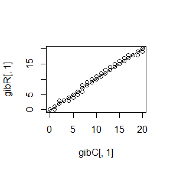

```r
library(Rcpp)

cppFunction('NumericMatrix gibbsC(int N, int thin, int n, int a, int b) {
  NumericMatrix mat(N, 2);
  double x = 10, y = 0.5;
  for(int i = 0; i < N; i++) {
    for(int j = 0; j < thin; j++) {
      x = rbinom(1, n, y)[0];
      y = rbeta(1, x + a, n - x + b)[0];
    }
    mat(i, 0) = x;
    mat(i, 1) = y;
  }
  return(mat);
}')

gibbsR <- function(N, thin, n, a, b) {
  mat <- matrix(nrow = N, ncol = 2)
  x <-10; y <- 0.5 #初值选为x = 10, y = 0.5
  for (i in 1:N) {
    for (j in 1:thin) {
      x <- rbinom(1, n, y)
      y <- rbeta(1, x + a, n - x + b)
    }
    mat[i, ] <- c(x, y)
  }
  mat
}

library(microbenchmark)
set.seed(1234)
a <- b <- 5;n <- 20;N <- 1000 #a,b,n,分别选为5,5,20; 生成数据总数为1000对
time<-microbenchmark(
  gibC <- gibbsC(N, 10, n, a, b),
  gibR <- gibbsR(N, 10, n, a, b)
)
qqplot(gibC[,1], gibR[,1])
abline(0,1)
```

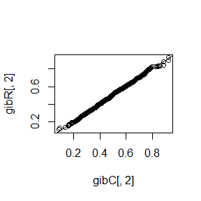

```r
qqplot(gibC[,2],gibR[,2])
abline(0,1)
```

```r
summary(time)
```

```
##                             expr       min        lq       mean     median
## 1 gibC <- gibbsC(N, 10, n, a, b)  4.497501  4.720702   8.233978   6.371601
## 2 gibR <- gibbsR(N, 10, n, a, b) 59.974600 64.324351 105.998751 101.984701
##         uq      max neval
## 1  10.7977  18.5827   100
## 2 132.6080 311.3846   100
```

通过qq图的对比, 点基本落在对角线附近或均匀分布在两侧, 可以发现gibbsR和gibbsC的随机数生成结果非常相似. 从耗时的对比来看, C++的生成速度是R的10多倍, 明显有更高的效率.